# cyclist

Christian Florez

2022-07-29

## ASK

For the actual data analysis project, there were 3 different questions proposed to be solved:

1. How do annual members and casual riders use Cyclistic bikes differently?
2. Why would casual riders buy Cyclistic annual memberships?
3. How can Cyclistic use digital media to influence casual riders to become members?

Lily Moreno our marketing director assigned me the question for research:

How do annual members and casual riders use Cyclistic bikes differently?

Financial analysts at Cyclistic have determined that in order to make the company more profitable it is necessary to get more memberships. That is why we need to answer the questions proposed. It is needed to have understandable and convincing insights on this answer to be able to let the marketing analyst group create the correct strategies to convert casual riders into memberships and then generate more value for the stakeholders.

## PREPARE

### Where is your data located?

The data used for this analysis is located at https://divvy-tripdata.s3.amazonaws.com/index.html.

### How is the data organized?

There are multiple datasets, there are one dataset for each month of the year, i am going to be Working with the last year data, so i’m gonna be using 12 different datasets with the same structure.

### Are there issues with bias or credibility in this data? Does your data ROCCC?

- It is primary data collected by the company.
- The company making available this datasets is DIVVY and is powered by Lyft, one of the biggest actors in the bike renting business throughout Citibike probably.

### ROCCC

Reliable: data seems to have enough information to answer the question, all data frame together have almost 6 million rows or observations, that seems to be fair to getinsights from it. Original: It is primary data. Comprehensive: features or columns have well named variables that can be understood easily and it seems like the question can be answered using the dataset. Current::data is well updated, it is possible to work with all last year data month by month. Cited: the data was made available by Motivate International Inc. so it is cited.

### How are you addressing licensing, privacy, security, and accessibility?

The license for this data let us grants to you a non-exclusive, royalty-free, limited, perpetual license to access, reproduce, analyze, copy, modify, distribute in your product or service and use the Data for any lawful purpose (“License”).

This dataset does not allow us to interact with sensible data like credit or debit cards of clients to see if the costumers live close to where they rented the bicycle, so we do not have access to names or personal information of costumers. this secure good data ethics for the actual research.

### How did you verify the data’s integrity?

Talking about physical integrity, i can say given the url direction it is well stored in the cloud using amazon web services and then talking about logical integrity i could say they are using entity integrity because we have a primary key in the table that make every observation unique, but do not have any information about referential, domain or any other logical integrity because do not have access to the database itself.

### How does it help you answer your question?

we have member_casual field that let us know if the person who made the ride was a member or a casual rider, then we can use other fields like stared and ended at to find out how long members or casuals rides took, also find out distances between stations and research if there are a correlation between one of these calculated features and the members_casual variable.

### Are there any problems with the data?

there are data that is missing, it can also have problems with withe spaces in cells but need to check first.

### View dataset

let’s see the first rows of our dataset.

```r
head(full_df)
```

```
## # A tibble: 6 × 13
##   ride_id        ridea…¹ started_at          ended_at            start…² start…³
##   <chr>          <chr>   <dttm>              <dttm>              <chr>   <chr>
## 1 0A1B623926EF4… docked… 2021-07-02 14:44:36 2021-07-02 15:19:58 Michig… 13001
## 2 B2D5583A5A5E7… classi… 2021-07-07 16:57:42 2021-07-07 17:16:09 Califo… 17660
## 3 6F264597DDBF4… classi… 2021-07-25 11:30:55 2021-07-25 11:48:45 Wabash… SL-012
## 4 379B58EAB20E8… classi… 2021-07-08 22:08:30 2021-07-08 22:23:32 Califo… 17660
## 5 6615C1E4EB08E… electr… 2021-07-28 16:08:06 2021-07-28 16:27:09 Califo… 17660
## 6 62DC2B32872F9… electr… 2021-07-29 17:09:08 2021-07-29 17:15:00 Califo… 17660
## # … with 7 more variables: end_station_name <chr>, end_station_id <chr>,
## #   start_lat <dbl>, start_lng <dbl>, end_lat <dbl>, end_lng <dbl>,
## #   member_casual <chr>, and abbreviated variable names ¹rideable_type,
## #   ²start_station_name, ³start_station_id
## # ℹ Use `colnames()` to see all variable names
```

### See structure and first rows

```r
str(full_df)
```

```
## spec_tbl_df [5,900,385 × 13] (S3: spec_tbl_df/tbl_df/tbl/data.frame)
##  $ ride_id           : chr [1:5900385] "0A1B623926EF4E16" "B2D5583A5A5E76EE" "6F264597DDBF427A" "379B58EAB20E8AA5" ...
##  $ rideable_type     : chr [1:5900385] "docked_bike" "classic_bike" "classic_bike" "classic_bike" ...
##  $ started_at        : POSIXct[1:5900385], format: "2021-07-02 14:44:36" "2021-07-07 16:57:42" ...
##  $ ended_at          : POSIXct[1:5900385], format: "2021-07-02 15:19:58" "2021-07-07 17:16:09" ...
##  $ start_station_name: chr [1:5900385] "Michigan Ave & Washington St" "California Ave & Cortez St" "Wabash Ave & 16th St" "California Ave & Cortez St" ...
##  $ start_station_id  : chr [1:5900385] "13001" "17660" "SL-012" "17660" ...
##  $ end_station_name  : chr [1:5900385] "Halsted St & North Branch St" "Wood St & Hubbard St" "Rush St & Hubbard St" "Carpenter St & Huron St" ...
##  $ end_station_id    : chr [1:5900385] "KA1504000117" "13432" "KA1503000044" "13196" ...
##  $ start_lat         : num [1:5900385] 41.9 41.9 41.9 41.9 41.9 ...
##  $ start_lng         : num [1:5900385] -87.6 -87.7 -87.6 -87.7 -87.7 ...
##  $ end_lat           : num [1:5900385] 41.9 41.9 41.9 41.9 41.9 ...
##  $ end_lng           : num [1:5900385] -87.6 -87.7 -87.6 -87.7 -87.7 ...
##  $ member_casual     : chr [1:5900385] "casual" "casual" "member" "member" ...
##  - attr(*, "spec")=
##   .. cols(
##   ..   ride_id = col_character(),
##   ..   rideable_type = col_character(),
##   ..   started_at = col_datetime(format = ""),
##   ..   ended_at = col_datetime(format = ""),
##   ..   start_station_name = col_character(),
##   ..   start_station_id = col_character(),
##   ..   end_station_name = col_character(),
##   ..   end_station_id = col_character(),
##   ..   start_lat = col_double(),
##   ..   start_lng = col_double(),
##   ..   end_lat = col_double(),
##   ..   end_lng = col_double(),
##   ..   member_casual = col_character()
##   .. )
##  - attr(*, "problems")=<externalptr>
```

```r
head(full_df)
```

```
## # A tibble: 6 × 13
##   ride_id        ridea…¹ started_at          ended_at            start…² start…³
##   <chr>          <chr>   <dttm>              <dttm>              <chr>   <chr>
## 1 0A1B623926EF4… docked… 2021-07-02 14:44:36 2021-07-02 15:19:58 Michig… 13001
## 2 B2D5583A5A5E7… classi… 2021-07-07 16:57:42 2021-07-07 17:16:09 Califo… 17660
## 3 6F264597DDBF4… classi… 2021-07-25 11:30:55 2021-07-25 11:48:45 Wabash… SL-012
## 4 379B58EAB20E8… classi… 2021-07-08 22:08:30 2021-07-08 22:23:32 Califo… 17660
## 5 6615C1E4EB08E… electr… 2021-07-28 16:08:06 2021-07-28 16:27:09 Califo… 17660
## 6 62DC2B32872F9… electr… 2021-07-29 17:09:08 2021-07-29 17:15:00 Califo… 17660
## # … with 7 more variables: end_station_name <chr>, end_station_id <chr>,
## #   start_lat <dbl>, start_lng <dbl>, end_lat <dbl>, end_lng <dbl>,
## #   member_casual <chr>, and abbreviated variable names ¹rideable_type,
## #   ²start_station_name, ³start_station_id
## # ℹ Use `colnames()` to see all variable names
```

### Sorting and filtering data

```r
full_df <- full_df %>%
  arrange(started_at)
head(full_df)
```

```
## # A tibble: 6 × 13
##   ride_id        ridea…¹ started_at          ended_at            start…² start…³
##   <chr>          <chr>   <dttm>              <dttm>              <chr>   <chr>
## 1 B8BA05857944F… electr… 2021-07-01 00:00:22 2021-07-01 00:04:51 <NA>    <NA>
## 2 B68C8C61487B5… classi… 2021-07-01 00:00:30 2021-07-01 00:46:58 Bissel… 13059
## 3 3FBF4B489DE3F… docked… 2021-07-01 00:00:42 2021-07-01 00:10:25 Clark … TA1309…
## 4 8A1D303852341… classi… 2021-07-01 00:00:47 2021-07-01 00:28:11 Michig… TA1305…
## 5 D5AA171FAE333… classi… 2021-07-01 00:00:53 2021-07-01 00:16:43 Wabash… TA1307…
## 6 D493F6B96A311… classi… 2021-07-01 00:01:53 2021-07-01 00:14:40 Halste… 13099
## # … with 7 more variables: end_station_name <chr>, end_station_id <chr>,
## #   start_lat <dbl>, start_lng <dbl>, end_lat <dbl>, end_lng <dbl>,
## #   member_casual <chr>, and abbreviated variable names ¹rideable_type,
## #   ²start_station_name, ³start_station_id
## # ℹ Use `colnames()` to see all variable names
```

## Data cleaning

### Tools

For data cleaning i will be using the tidyverse for data manipulation, janitor to use functions to cleaning data, skimr for data summarization and here packages.

### Data Integrity

The dataset was given to me by a primary source, but i don’t have physical access to the databases to understand and check everything about data integrity but what i can actually see is that every ride has a ride_id that looks like it is a primary key for the table we are using. I want to check if every trip is different and there are no duplicates using this field.

```r
length(unique(full_df$ride_id))
```

```
## [1] 5900385
```

As we can see we got 5.900.385 observations that are exactly the same amount of observations we have in our full dataset, it means every obsevation is unique.

### Steps for data cleaning

#### Creating a new dataset

```r
trips_info <- full_df %>%
  select(-ride_id,-start_station_id,-end_station_id)
head(trips_info)
```

```
## # A tibble: 6 × 10
##   rideable_type started_at          ended_at            start_…¹ end_s…² start…³
##   <chr>         <dttm>              <dttm>              <chr>    <chr>     <dbl>
## 1 electric_bike 2021-07-01 00:00:22 2021-07-01 00:04:51 <NA>     State …    41.8
## 2 classic_bike  2021-07-01 00:00:30 2021-07-01 00:46:58 Bissell… Lincol…    41.9
## 3 docked_bike   2021-07-01 00:00:42 2021-07-01 00:10:25 Clark S… Broadw…    42.0
## 4 classic_bike  2021-07-01 00:00:47 2021-07-01 00:28:11 Michiga… Wabash…    41.9
## 5 classic_bike  2021-07-01 00:00:53 2021-07-01 00:16:43 Wabash … Wells …    41.9
## 6 classic_bike  2021-07-01 00:01:53 2021-07-01 00:14:40 Halsted… Morgan…    41.9
## # … with 4 more variables: start_lng <dbl>, end_lat <dbl>, end_lng <dbl>,
## #   member_casual <chr>, and abbreviated variable names ¹start_station_name,
## #   ²end_station_name, ³start_lat
## # ℹ Use `colnames()` to see all variable names
```

let’s change some columns names to make them more understandable, riddable_type will be renamed as bike_type and member_casual as user_type

```r
trips_info <- trips_info %>%
  rename(user_type = member_casual) %>%
  rename(bike_type =  rideable_type)
head(trips_info)
```

```
## # A tibble: 6 × 10
##   bike_type     started_at          ended_at            start_…¹ end_s…² start…³
##   <chr>         <dttm>              <dttm>              <chr>    <chr>     <dbl>
## 1 electric_bike 2021-07-01 00:00:22 2021-07-01 00:04:51 <NA>     State …    41.8
## 2 classic_bike  2021-07-01 00:00:30 2021-07-01 00:46:58 Bissell… Lincol…    41.9
## 3 docked_bike   2021-07-01 00:00:42 2021-07-01 00:10:25 Clark S… Broadw…    42.0
## 4 classic_bike  2021-07-01 00:00:47 2021-07-01 00:28:11 Michiga… Wabash…    41.9
## 5 classic_bike  2021-07-01 00:00:53 2021-07-01 00:16:43 Wabash … Wells …    41.9
## 6 classic_bike  2021-07-01 00:01:53 2021-07-01 00:14:40 Halsted… Morgan…    41.9
## # … with 4 more variables: start_lng <dbl>, end_lat <dbl>, end_lng <dbl>,
## #   user_type <chr>, and abbreviated variable names ¹start_station_name,
## #   ²end_station_name, ³start_lat
## # ℹ Use `colnames()` to see all variable names
```

I am also going to include new calculated fields like day of week, month year and trip duration in minutes.

Let’s start creating trip_duration_min.

```r
trips_info <- trips_info %>%
  mutate(trip_duration_min = as.numeric(difftime(ended_at,started_at),units = "mins"))
head(trips_info)
```

```
## # A tibble: 6 × 11
##   bike_type     started_at          ended_at            start_…¹ end_s…² start…³
##   <chr>         <dttm>              <dttm>              <chr>    <chr>     <dbl>
## 1 electric_bike 2021-07-01 00:00:22 2021-07-01 00:04:51 <NA>     State …    41.8
## 2 classic_bike  2021-07-01 00:00:30 2021-07-01 00:46:58 Bissell… Lincol…    41.9
## 3 docked_bike   2021-07-01 00:00:42 2021-07-01 00:10:25 Clark S… Broadw…    42.0
## 4 classic_bike  2021-07-01 00:00:47 2021-07-01 00:28:11 Michiga… Wabash…    41.9
## 5 classic_bike  2021-07-01 00:00:53 2021-07-01 00:16:43 Wabash … Wells …    41.9
## 6 classic_bike  2021-07-01 00:01:53 2021-07-01 00:14:40 Halsted… Morgan…    41.9
## # … with 5 more variables: start_lng <dbl>, end_lat <dbl>, end_lng <dbl>,
## #   user_type <chr>, trip_duration_min <dbl>, and abbreviated variable names
## #   ¹start_station_name, ²end_station_name, ³start_lat
## # ℹ Use `colnames()` to see all variable names
```

Now let’s create a new feature with weekdays

```r
trips_info$day_of_week <- format(as.Date(trips_info$started_at),"%a")
head(trips_info)
```

```
## # A tibble: 6 × 12
##   bike_type     started_at          ended_at            start_…¹ end_s…² start…³
##   <chr>         <dttm>              <dttm>              <chr>    <chr>     <dbl>
## 1 electric_bike 2021-07-01 00:00:22 2021-07-01 00:04:51 <NA>     State …    41.8
## 2 classic_bike  2021-07-01 00:00:30 2021-07-01 00:46:58 Bissell… Lincol…    41.9
## 3 docked_bike   2021-07-01 00:00:42 2021-07-01 00:10:25 Clark S… Broadw…    42.0
## 4 classic_bike  2021-07-01 00:00:47 2021-07-01 00:28:11 Michiga… Wabash…    41.9
## 5 classic_bike  2021-07-01 00:00:53 2021-07-01 00:16:43 Wabash … Wells …    41.9
## 6 classic_bike  2021-07-01 00:01:53 2021-07-01 00:14:40 Halsted… Morgan…    41.9
## # … with 6 more variables: start_lng <dbl>, end_lat <dbl>, end_lng <dbl>,
## #   user_type <chr>, trip_duration_min <dbl>, day_of_week <chr>, and
## #   abbreviated variable names ¹start_station_name, ²end_station_name,
## #   ³start_lat
## # ℹ Use `colnames()` to see all variable names
```

The last column i am creating will be months, it would be interesting to compare months later on.

```r
trips_info$year_month <- format(as.Date(trips_info$started_at),"%Y-%m")
head(trips_info)
```

```
## # A tibble: 6 × 13
##   bike_type     started_at          ended_at            start_…¹ end_s…² start…³
##   <chr>         <dttm>              <dttm>              <chr>    <chr>     <dbl>
## 1 electric_bike 2021-07-01 00:00:22 2021-07-01 00:04:51 <NA>     State …    41.8
## 2 classic_bike  2021-07-01 00:00:30 2021-07-01 00:46:58 Bissell… Lincol…    41.9
## 3 docked_bike   2021-07-01 00:00:42 2021-07-01 00:10:25 Clark S… Broadw…    42.0
## 4 classic_bike  2021-07-01 00:00:47 2021-07-01 00:28:11 Michiga… Wabash…    41.9
## 5 classic_bike  2021-07-01 00:00:53 2021-07-01 00:16:43 Wabash … Wells …    41.9
## 6 classic_bike  2021-07-01 00:01:53 2021-07-01 00:14:40 Halsted… Morgan…    41.9
## # … with 7 more variables: start_lng <dbl>, end_lat <dbl>, end_lng <dbl>,
## #   user_type <chr>, trip_duration_min <dbl>, day_of_week <chr>,
## #   year_month <chr>, and abbreviated variable names ¹start_station_name,
## #   ²end_station_name, ³start_lat
## # ℹ Use `colnames()` to see all variable names
```

#### Look for inconsistencies in the new dataset

I want to check if the new dataset has missing values.

```r
cbind(lapply(lapply(trips_info, is.na), sum))
```

```
##                    [,1]
## bike_type          0
## started_at         0
## ended_at           0
## start_station_name 836018
## end_station_name   892103
## start_lat          0
## start_lng          0
## end_lat            5374
## end_lng            5374
## user_type          0
## trip_duration_min  0
## day_of_week        0
## year_month         0
```

Last command shows there are some missing values but just in 4 features end_lat, end_lng, start_station_name and end_station_name, so i won’t delete them because i can still make calculation with the features that have complete observations. Then i want to check for any inconsistencies in the dataset using the summary function.

```r
trips_info %>%
  summary()
```

```
##   bike_type           started_at
##  Length:5900385     Min.   :2021-07-01 00:00:22.00
##  Class :character   1st Qu.:2021-08-26 07:57:58.00
##  Mode  :character   Median :2021-10-27 17:35:55.00
##                     Mean   :2021-12-12 00:11:36.51
##                     3rd Qu.:2022-04-25 13:41:23.00
##                     Max.   :2022-06-30 23:59:58.00
##
##     ended_at                      start_station_name end_station_name
##  Min.   :2021-07-01 00:04:51.00   Length:5900385     Length:5900385
##  1st Qu.:2021-08-26 08:11:00.00   Class :character   Class :character
##  Median :2021-10-27 17:49:46.00   Mode  :character   Mode  :character
##  Mean   :2021-12-12 00:31:53.47
##  3rd Qu.:2022-04-25 13:57:17.00
##  Max.   :2022-07-13 04:21:06.00
##
##    start_lat       start_lng         end_lat         end_lng
##  Min.   :41.64   Min.   :-87.84   Min.   :41.39   Min.   :-88.97
##  1st Qu.:41.88   1st Qu.:-87.66   1st Qu.:41.88   1st Qu.:-87.66
##  Median :41.90   Median :-87.64   Median :41.90   Median :-87.64
##  Mean   :41.90   Mean   :-87.65   Mean   :41.90   Mean   :-87.65
##  3rd Qu.:41.93   3rd Qu.:-87.63   3rd Qu.:41.93   3rd Qu.:-87.63
##  Max.   :45.64   Max.   :-73.80   Max.   :42.17   Max.   :-87.49
##                                   NA's   :5374    NA's   :5374
##   user_type         trip_duration_min  day_of_week         year_month
##  Length:5900385     Min.   : -137.42   Length:5900385     Length:5900385
##  Class :character   1st Qu.:    6.28   Class :character   Class :character
##  Mode  :character   Median :   11.17   Mode  :character   Mode  :character
##                     Mean   :   20.28
##                     3rd Qu.:   20.20
##                     Max.   :49107.15
##
```

Revising the results from the summary function on this dataset, we can see there is something wrong with the trip_duration_min feature because it says there are one or more negative duration and it can not be possible so i want to understand how many observations we have with this kind of error first.

```r
  sum(trips_info$trip_duration_min <= 0)
```

```
## [1] 646
```

We now can see that this dataset have 646 observations where the trip_duration is negative, so were going to delete those observations because we have 5.900.385 and for now we have 646 bad observations that can skew our results. it is just 0.0001094844 so it is not going to be very representative. I am also going to create a new dataset to keep dataframe Versioning.

```r
  trips_info_v2 <- trips_info[!(trips_info$trip_duration_min <= 0), ]
  sum(trips_info_v2$trip_duration_min <= 0)
```

```
## [1] 0
```

Our new dataset does not have any negative duration. But if we take a look to trips duration again we are seeing that the max duration is 49.107 min, that it’s approximately 34.08 days, that is weird but can happen. maybe someone lost it’s bike and did’nt report it, maybe someone just didn’t locked up the bike correctly and another person stole it, could be a lot of different scenarios in the real life i should call the company and ask questions to figure out what happened.

## ANALYZE

Let’s make an overview of our data understanding for example how many observations members and casual riders this dataset have (we have to have in mindl that the ride_id is making unique the ride itself not the users, this means that it is posible that in those observations there are users that made rides multiple times).

```r
trips_info_v2 %>%
  count(user_type)
```

```
## # A tibble: 2 × 2
##   user_type       n
##   <chr>       <int>
## 1 casual    2557887
## 2 member    3341852
```

Now it would be interesting to find out what is the descriptive statistic of duration for each group, members and casuals. let’s see.

### Desscriptive statistics user_type Vs trip_duration_min

Let’s check the mean

```r
trips_info_v2 %>%
  group_by(user_type)%>%
  summarize(mean_user = mean(trip_duration_min))
```

```
## # A tibble: 2 × 2
##   user_type mean_user
##   <chr>         <dbl>
## 1 casual         29.8
## 2 member         13.0
```

It is interesting to find out that the casual riders use the bicycles for longer time than the members in average. this is going to be a useful information to create a strategy with this information later on.

Now let’s check the min.

```r
trips_info_v2 %>%
  group_by(user_type)%>%
  summarize(min_user = min(trip_duration_min))
```

```
## # A tibble: 2 × 2
##   user_type min_user
##   <chr>        <dbl>
## 1 casual      0.0167
## 2 member      0.0167
```

Now let’s check the max.

```r
trips_info_v2 %>%
  group_by(user_type)%>%
  summarize(max_user = max(trip_duration_min))
```

```
## # A tibble: 2 × 2
##   user_type max_user
##   <chr>        <dbl>
## 1 casual      49107.
## 2 member       1560.
```

### Desscriptive statistics user_type, trip_duration_min & day_of_week

Now lets find out relationships between this variables to have some insights.

Let’s check the mean

```r
trips_info_v2 %>%
  group_by(user_type, day_of_week)%>%
  summarize(mean_user_trip_duration = mean(trip_duration_min))
```

```
## # A tibble: 14 × 3
## # Groups:   user_type [2]
##    user_type day_of_week mean_user_trip_duration
##    <chr>     <chr>                         <dbl>
##  1 casual    Fri                            28.3
##  2 casual    Mon                            30.6
##  3 casual    Sat                            32.2
##  4 casual    Sun                            34.5
##  5 casual    Thu                            27.2
##  6 casual    Tue                            25.7
##  7 casual    Wed                            25.7
##  8 member    Fri                            12.7
##  9 member    Mon                            12.6
## 10 member    Sat                            14.5
## 11 member    Sun                            14.7
## 12 member    Thu                            12.5
## 13 member    Tue                            12.2
## 14 member    Wed                            12.2
```

If we take a look to this results we found that casual riders at least double the members in every single dy by trip duration. This is pretty interesting because maybe, the casual riders are spending more without noticing that it would be cheaper to have a membership (but to completely solve this issue we would need more information).

Let’s check the min

```r
trips_info_v2 %>%
  group_by(user_type, day_of_week)%>%
  summarize(min_user_trip_duration = min(trip_duration_min))
```

```
## # A tibble: 14 × 3
## # Groups:   user_type [2]
##    user_type day_of_week min_user_trip_duration
##    <chr>     <chr>                        <dbl>
##  1 casual    Fri                         0.0167
##  2 casual    Mon                         0.0167
##  3 casual    Sat                         0.0167
##  4 casual    Sun                         0.0167
##  5 casual    Thu                         0.0167
##  6 casual    Tue                         0.0167
##  7 casual    Wed                         0.0167
##  8 member    Fri                         0.0167
##  9 member    Mon                         0.0167
## 10 member    Sat                         0.0167
## 11 member    Sun                         0.0167
## 12 member    Thu                         0.0167
## 13 member    Tue                         0.0167
## 14 member    Wed                         0.0167
```

Let’s check the max

```r
trips_info_v2 %>%
  group_by(user_type, day_of_week)%>%
  summarize(max_user_trip_duration = max(trip_duration_min))
```

```
## # A tibble: 14 × 3
## # Groups:   user_type [2]
##    user_type day_of_week max_user_trip_duration
##    <chr>     <chr>                        <dbl>
##  1 casual    Fri                         38685.
##  2 casual    Mon                         31031.
##  3 casual    Sat                         40725.
##  4 casual    Sun                         41629.
##  5 casual    Thu                         49107.
##  6 casual    Tue                         25008.
##  7 casual    Wed                         35821.
##  8 member    Fri                          1500.
##  9 member    Mon                          1500.
## 10 member    Sat                          1560.
## 11 member    Sun                          1500.
## 12 member    Thu                          1500.
## 13 member    Tue                          1500.
## 14 member    Wed                          1500.
```

### Desscriptive statistics user_type, trip_duration_min & year_month

Let’s find out relationships between this variables to have some insights.

Let’s check the mean

```r
trips_info_v2 %>%
  group_by(user_type,year_month)%>%
  summarize(mean_user_trip_duration = mean(trip_duration_min))
```

```
## # A tibble: 24 × 3
## # Groups:   user_type [2]
##    user_type year_month mean_user_trip_duration
##    <chr>     <chr>                        <dbl>
##  1 casual    2021-07                       32.8
##  2 casual    2021-08                       28.8
##  3 casual    2021-09                       27.8
##  4 casual    2021-10                       28.7
##  5 casual    2021-11                       23.1
##  6 casual    2021-12                       23.5
##  7 casual    2022-01                       30.4
##  8 casual    2022-02                       26.7
##  9 casual    2022-03                       32.6
## 10 casual    2022-04                       29.5
## # … with 14 more rows
## # ℹ Use `print(n = ...)` to see more rows
```

Let’s check the min

```r
trips_info_v2 %>%
  group_by(user_type, year_month)%>%
  summarize(min_user_trip_duration = min(trip_duration_min))
```

```
## # A tibble: 24 × 3
## # Groups:   user_type [2]
##    user_type year_month min_user_trip_duration
##    <chr>     <chr>                       <dbl>
##  1 casual    2021-07                    0.0167
##  2 casual    2021-08                    0.0167
##  3 casual    2021-09                    0.0167
##  4 casual    2021-10                    0.0167
##  5 casual    2021-11                    0.0167
##  6 casual    2021-12                    0.0167
##  7 casual    2022-01                    0.0167
##  8 casual    2022-02                    0.0167
##  9 casual    2022-03                    0.0167
## 10 casual    2022-04                    0.0167
## # … with 14 more rows
## # ℹ Use `print(n = ...)` to see more rows
```

Let’s check the max

```r
trips_info_v2 %>%
  group_by(user_type, year_month)%>%
  summarize(max_user_trip_duration = max(trip_duration_min))
```

```
## # A tibble: 24 × 3
## # Groups:   user_type [2]
##    user_type year_month max_user_trip_duration
##    <chr>     <chr>                       <dbl>
##  1 casual    2021-07                    49107.
##  2 casual    2021-08                    41629.
##  3 casual    2021-09                    32859.
##  4 casual    2021-10                    40705.
##  5 casual    2021-11                    34998.
##  6 casual    2021-12                    30401.
##  7 casual    2022-01                    29271.
##  8 casual    2022-02                    10906.
##  9 casual    2022-03                    34354.
## 10 casual    2022-04                    21122.
## # … with 14 more rows
## # ℹ Use `print(n = ...)` to see more rows
```

### Descriptive statistics user_type, bike_type

let’s take a look of the relation between user type and the bike type, we are staring with the number of rides.

```r
trips_info_v2 %>%
 group_by(user_type, bike_type) %>%
 summarize(number_of_rides = n())
```

```
## # A tibble: 5 × 3
## # Groups:   user_type [2]
##   user_type bike_type     number_of_rides
##   <chr>     <chr>                   <int>
## 1 casual    classic_bike          1218178
## 2 casual    docked_bike            253364
## 3 casual    electric_bike         1086345
## 4 member    classic_bike          1970959
## 5 member    electric_bike         1370893
```

Let’s calculate the mean.

```r
trips_info_v2 %>%
 group_by(user_type, bike_type) %>%
 summarize(mean_user_bike_duration = mean(trip_duration_min))
```

```
## # A tibble: 5 × 3
## # Groups:   user_type [2]
##   user_type bike_type     mean_user_bike_duration
##   <chr>     <chr>                           <dbl>
## 1 casual    classic_bike                     28.5
## 2 casual    docked_bike                      85.3
## 3 casual    electric_bike                    18.4
## 4 member    classic_bike                     13.7
## 5 member    electric_bike                    11.9
```

Now let’s continue with the min

```r
trips_info_v2 %>%
 group_by(user_type, bike_type) %>%
 summarize(min_user_bike_duration = min(trip_duration_min))
```

```
## # A tibble: 5 × 3
## # Groups:   user_type [2]
##   user_type bike_type     min_user_bike_duration
##   <chr>     <chr>                          <dbl>
## 1 casual    classic_bike                  0.0167
## 2 casual    docked_bike                   0.0167
## 3 casual    electric_bike                 0.0167
## 4 member    classic_bike                  0.0167
## 5 member    electric_bike                 0.0167
```

let’s find with the max

```r
trips_info_v2 %>%
 group_by(user_type, bike_type) %>%
 summarize(max_user_bike_duration = max(trip_duration_min))
```

```
## # A tibble: 5 × 3
## # Groups:   user_type [2]
##   user_type bike_type     max_user_bike_duration
##   <chr>     <chr>                          <dbl>
## 1 casual    classic_bike                   1560.
## 2 casual    docked_bike                   49107.
## 3 casual    electric_bike                   487.
## 4 member    classic_bike                   1560.
## 5 member    electric_bike                   614.
```

### Descriptive statistics user_type, start_station_name

I want to see how many rides members did depending of the station.

```r
trips_info_v2 %>%
 filter(user_type == "member") %>%
 count(start_station_name, sort = T)
```

```
## # A tibble: 1,183 × 2
##    start_station_name                n
##    <chr>                         <int>
##  1 <NA>                         476042
##  2 Kingsbury St & Kinzie St      26246
##  3 Clark St & Elm St             24186
##  4 Wells St & Concord Ln         23908
##  5 Wells St & Elm St             21157
##  6 Ellis Ave & 60th St           19786
##  7 Clinton St & Madison St       19396
##  8 University Ave & 57th St      19303
##  9 Clinton St & Washington Blvd  19168
## 10 Dearborn St & Erie St         18964
## # … with 1,173 more rows
## # ℹ Use `print(n = ...)` to see more rows
```

We can see we have some missing values, but we have enough to make insights. We can see the top ten stations.

Now let’s do the same but for casual riders.

```r
trips_info_v2 %>%
 filter(user_type == "casual") %>%
 count(start_station_name, sort = T)
```

```
## # A tibble: 1,253 × 2
##    start_station_name                      n
##    <chr>                               <int>
##  1 <NA>                               359946
##  2 Streeter Dr & Grand Ave             65470
##  3 Millennium Park                     30812
##  4 DuSable Lake Shore Dr & Monroe St   29315
##  5 Michigan Ave & Oak St               28745
##  6 DuSable Lake Shore Dr & North Blvd  24323
##  7 Shedd Aquarium                      22491
##  8 Theater on the Lake                 20800
##  9 Wells St & Concord Ln               19581
## 10 Clark St & Lincoln Ave              16223
## # … with 1,243 more rows
## # ℹ Use `print(n = ...)` to see more rows
```

If we compare both casuals and members we are seeing that the top 10 are different for each category.

have to research what kind of places those stations are close to?

let’s do the same with where the trips ended for each category. I am staring with members.

```r
trips_info_v2 %>%
 filter(user_type == "member") %>%
 count(end_station_name, sort = T)
```

```
## # A tibble: 1,177 × 2
##    end_station_name                  n
##    <chr>                         <int>
##  1 <NA>                         474740
##  2 Kingsbury St & Kinzie St      26021
##  3 Wells St & Concord Ln         24586
##  4 Clark St & Elm St             24382
##  5 Wells St & Elm St             21446
##  6 Clinton St & Madison St       19990
##  7 Clinton St & Washington Blvd  19989
##  8 University Ave & 57th St      19876
##  9 Dearborn St & Erie St         19316
## 10 Ellis Ave & 60th St           19287
## # … with 1,167 more rows
## # ℹ Use `print(n = ...)` to see more rows
```

let’s ask the same for casuals.

```r
trips_info_v2 %>%
 filter(user_type == "casual") %>%
 count(end_station_name, sort = T)
```

```
## # A tibble: 1,259 × 2
##    end_station_name                        n
##    <chr>                               <int>
##  1 <NA>                               416979
##  2 Streeter Dr & Grand Ave             67584
##  3 Millennium Park                     31775
##  4 Michigan Ave & Oak St               30158
##  5 DuSable Lake Shore Dr & North Blvd  27928
##  6 DuSable Lake Shore Dr & Monroe St   27120
##  7 Theater on the Lake                 21905
##  8 Shedd Aquarium                      21292
##  9 Wells St & Concord Ln               18815
## 10 Clark St & Lincoln Ave              16136
## # … with 1,249 more rows
## # ℹ Use `print(n = ...)` to see more rows
```

## SHARE

### Average duration per ride by day of the week and type of user in minutes.

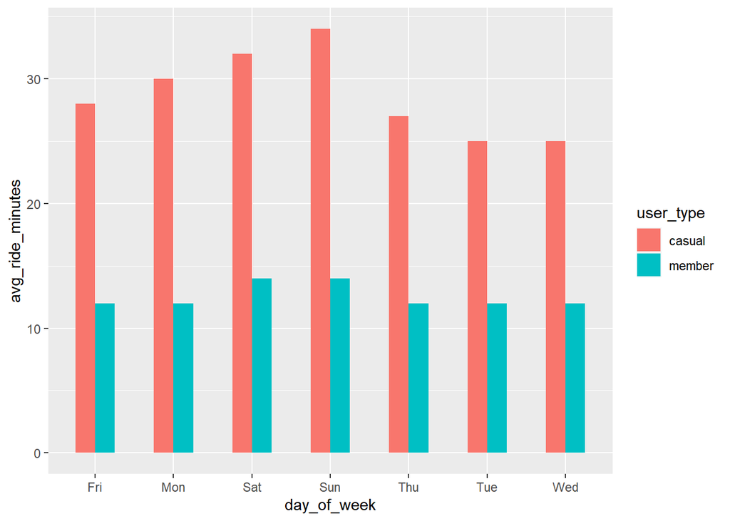

```r
trips_info_v2 %>%
     arrange(day_of_week)%>%
     group_by(day_of_week, user_type) %>%
     summarise(avg_ride_minutes = as.integer(mean(trip_duration_min))) %>%
     ggplot(aes(x = day_of_week, y = avg_ride_minutes, fill = user_type)) +
     geom_col(width = 0.5, position = position_dodge(0.5))
```

Saturday and sunday are the days when riders use the bikes for longer periods of time in both categories casuals and members, we also can see that casual users have longer rides than members every day.

### Count of rides by user type and day of the week

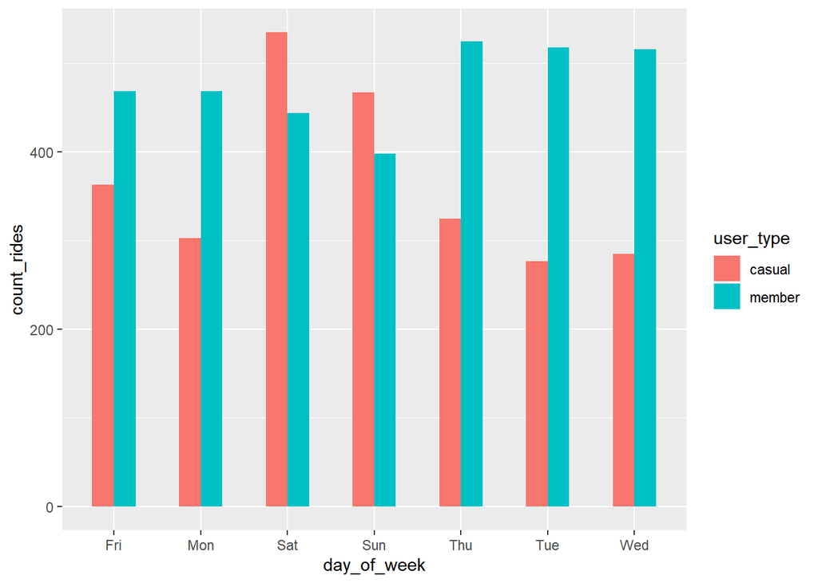

```r
trips_info_v2 %>%
     group_by(day_of_week, user_type) %>%
     summarise(count_rides = as.integer(n()/1000)) %>%
     ggplot(aes(x = day_of_week, y = count_rides, fill = user_type)) +
     geom_col(width = 0.5, position = position_dodge(0.5))
```

### Average duration per ride by moth year and type of user in minutes.

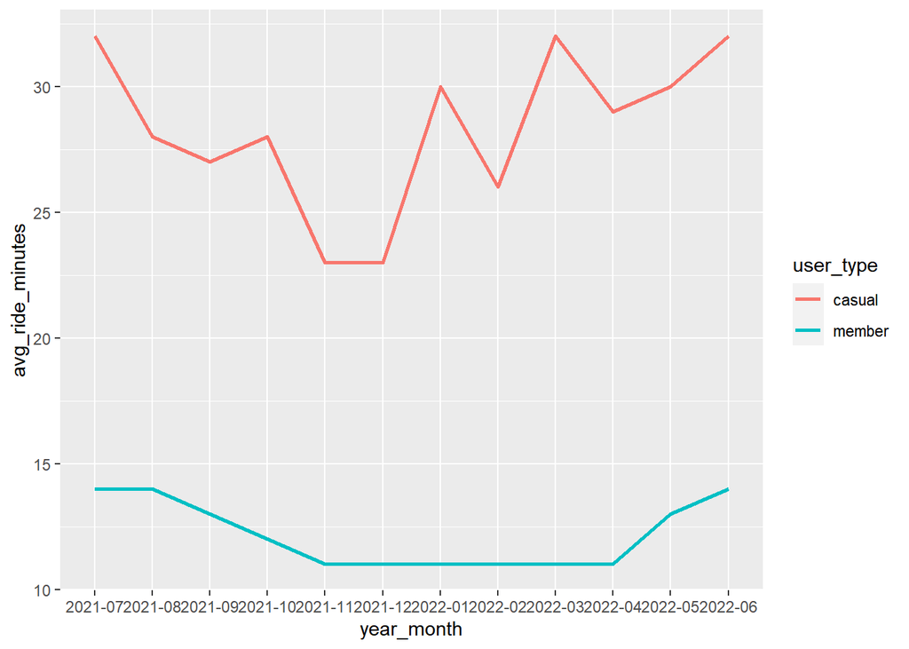

```r
trips_info_v2 %>%
     group_by(year_month, user_type) %>%
     summarise(avg_ride_minutes = as.integer(mean(trip_duration_min))) %>%
     ggplot(aes(x = year_month, y = avg_ride_minutes, color = user_type, group = user_type)) +
     geom_line(size = 1)
```

### Count of rides by months and user type

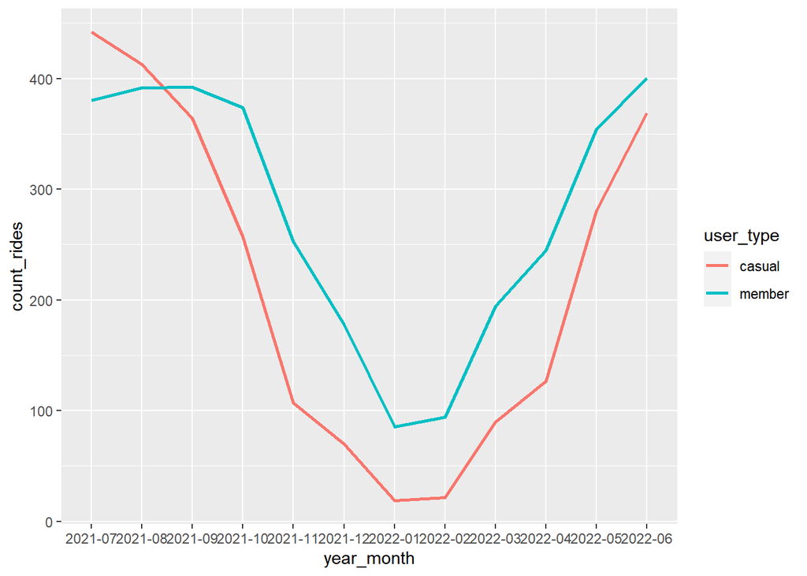

```r
trips_info_v2 %>%
     group_by(year_month, user_type) %>%
     summarise(count_rides = n()/1000) %>%
     ggplot(aes(x = year_month, y = count_rides, color = user_type, group = user_type)) +
     geom_line(size = 1)
```

### Count total trips last year by user type

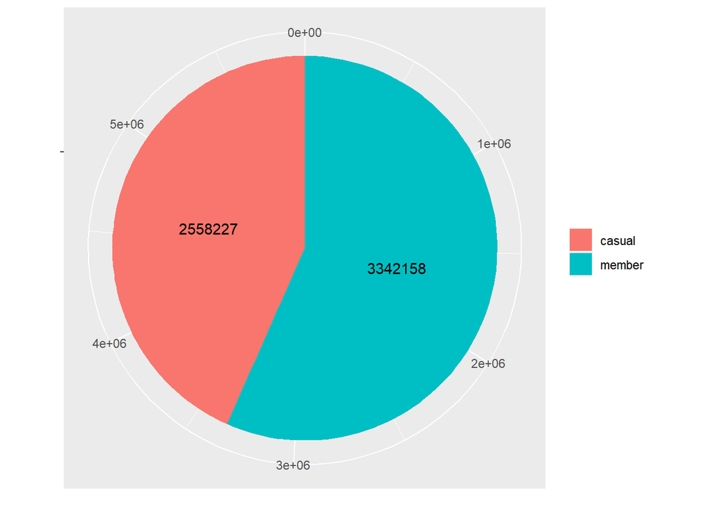

```r
trips_info %>%
    group_by(user_type) %>%
    summarise(count_rides = n()) %>%
    ggplot(aes(x="", y = count_rides, fill=user_type)) +
    geom_bar(stat="identity", width=1) +
    coord_polar("y", start=0) +
    geom_text(aes(label = paste(c(count_rides[1], count_rides[2]), "")), position =                             position_stack(vjust=0.5)) +
    labs(x = NULL, y = NULL, fill = NULL)
```

## ACT

### Recomendations

It would be insightful to have some financial indicators or financial statements to try to give a better recommendations. having information on how is the revenue and cost structure would be variable. Also having another variables in the dataset like if the user is local or if it is tourist would be insightful.